# Jakob Bindas CS 1675 Final Project

2024-04-12

## Final Project: Exploration

This Rmd file provides my solutions to data exploration of the provided data file. Solutions for my regression modeling & interpretations can be found in Bindas_Jakob_Regression.Rmd while those for classification modeling & interpretations can be found in Bindas_Jakob_Classification.Rmd

### Load in packages

```r
library(caret)
library(tidyverse)
```

Load in the data. Important response names are $\textbf{response}$ and $\textbf{outcome}$. $\textbf{response}$ is used for the regression tasks and $\textbf{outcome}$ is used for the classification tasks (event = 1, non-event = 0; popular vs less popular paints)

```r
df <- readr::read_csv('paint_project_train_data-1.csv', col_names = TRUE)
df %>% head()
```

```
## # A tibble: 6 × 8
##       R     G     B Lightness Saturation   Hue response outcome
##   <dbl> <dbl> <dbl> <chr>     <chr>      <dbl>    <dbl>   <dbl>
## 1   172    58    62 dark      bright         4       12       1
## 2    26    88   151 dark      bright        31       10       1
## 3   172    94    58 dark      bright         8       16       1
## 4    28    87   152 dark      bright        32       10       0
## 5   170    66    58 dark      bright         5       11       0
## 6   175    89    65 dark      bright         6       16       0
```

## Project Goals

Primary goals of the project are associated with learning which INPUTS are important!

- Regression task: Train models to predict the important paint property, response, as a function of the color model INPUTS.
  - Want to learn how the color model INPUTS influence the important paint property!
  - Are the inputs from one color model more influential on predicting the important paint property?

## Inputs and Color Models

- The INPUTS are associated with two alternative color models.
- The R, G, and B INPUTS are the RGB values from the RGB color model.
- The Hue, Saturation, and Lightness INPUTS are HSL associated values from the HSL color model.
  - Continuous: R, G, B, Hue
  - Categorical: Lightness, Saturation

====================================================================

## 1. Exploration

### A. Visualize categorical variables

#### Counts for categorical variables

##### a.

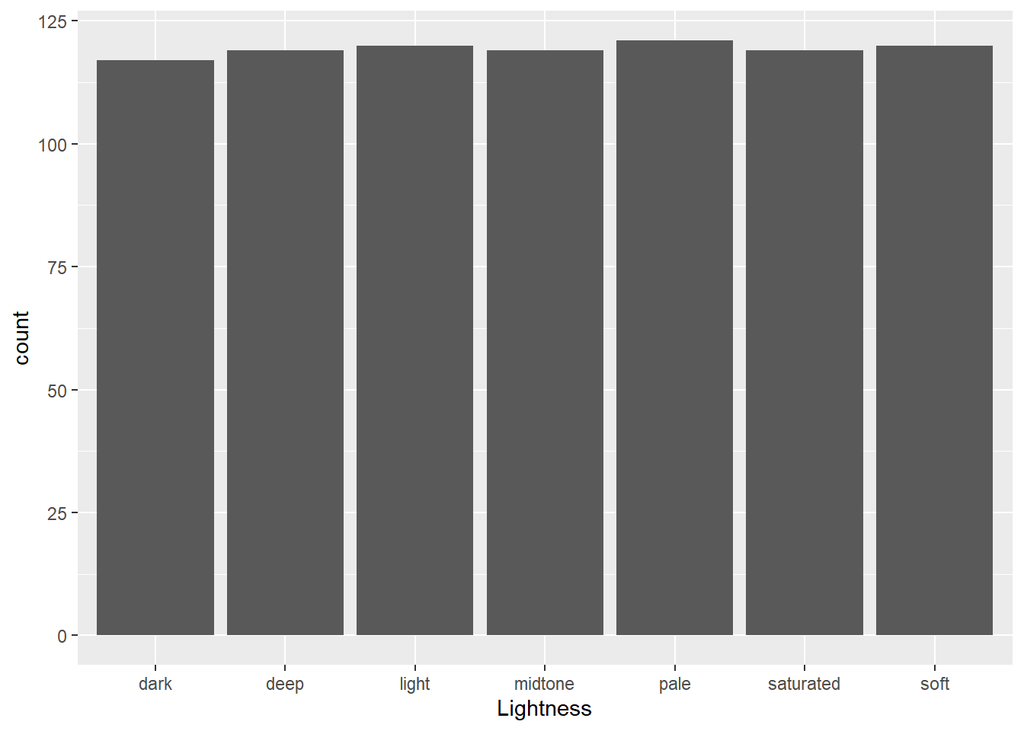

```r
df %>%
  ggplot(mapping=aes(x=Lightness)) +
  geom_bar()
```

Counts are fairly close for each type of Lightness

##### b.

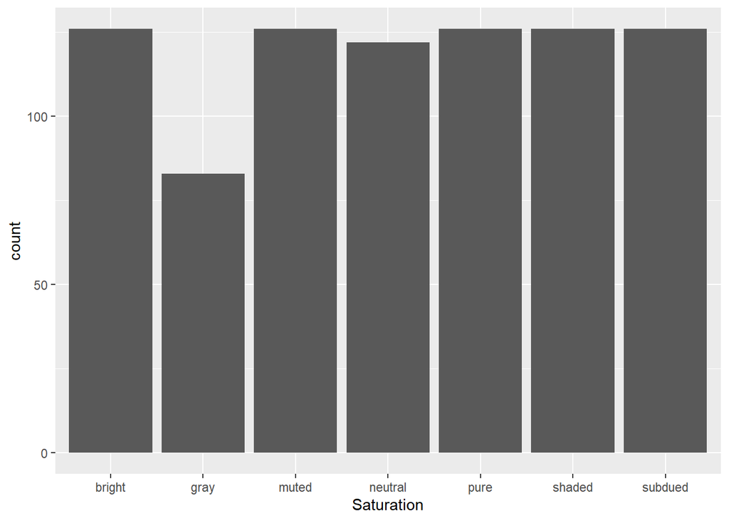

```r
df %>%
  ggplot(mapping=aes(x=Saturation)) +
  geom_bar()
```

Counts are fairly close for each Saturation, minus gray - has significantly less counts than the rest

##### c.

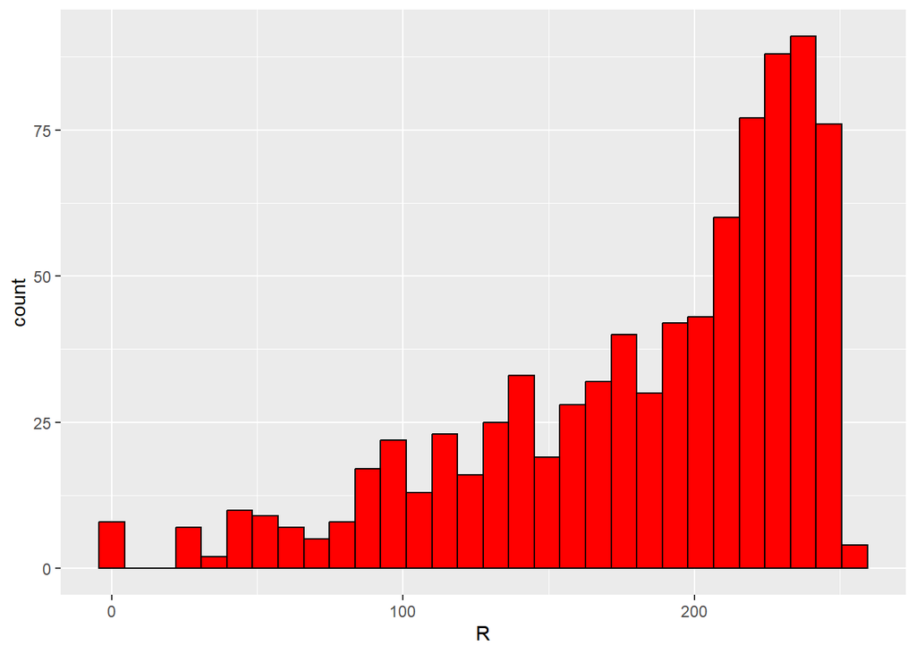

```r
df %>%
  ggplot() +
  geom_histogram(mapping=aes(x=R), color='black', fill='red')
```

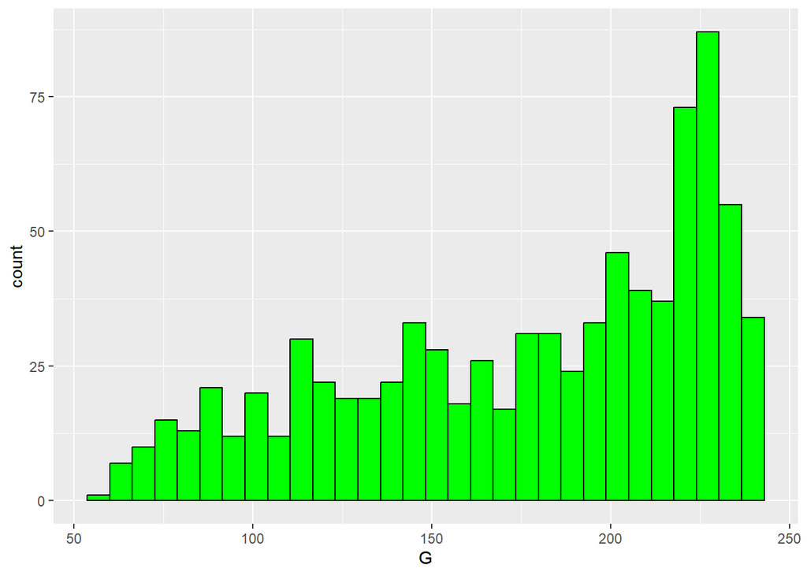

```r
df %>%
  ggplot() +
  geom_histogram(mapping=aes(x=G), color='black', fill='green')
```

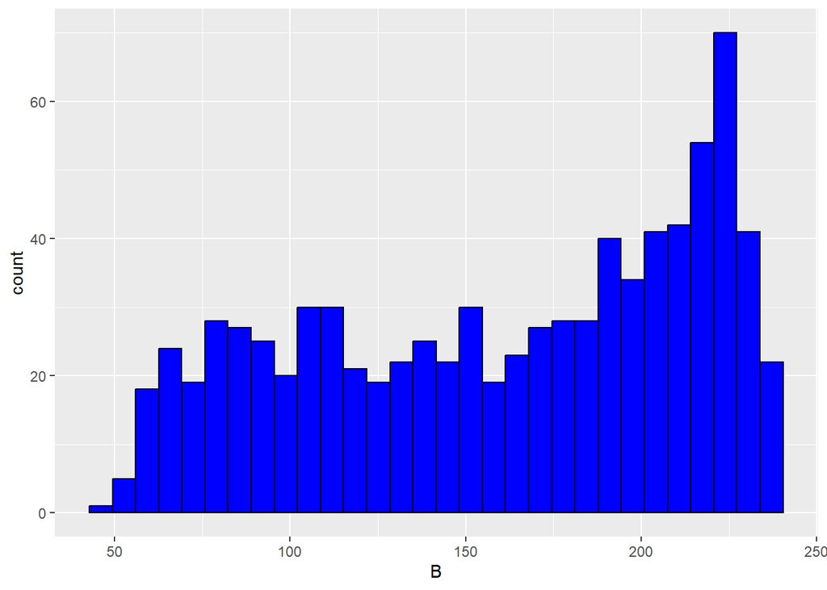

```r
df %>%
  ggplot() +
  geom_histogram(mapping=aes(x=B), color='black', fill='blue')
```

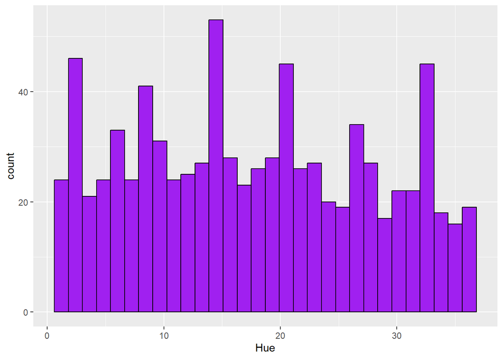

```r
df %>%
  ggplot() +
  geom_histogram(mapping=aes(x=Hue), color='black', fill='purple')
```

The three color RGB values each appear to share the same shape. They are not Gaussian in shape and have a skewed left distribution - the majority of values are peaked around 225 for each. The Hue input does not really have a shape and appears to be have a random shape.

#### d. Summary Statistics

```r
summary_R <- summary(df$R)
summary_G <- summary(df$G)
summary_B <- summary(df$B)
summary_Hue <- summary(df$Hue)

sumtable_inputs <- rbind(summary_R, summary_G, summary_B, summary_Hue)
sumtable_inputs
```

```
##             Min. 1st Qu. Median      Mean 3rd Qu. Max.
## summary_R      0   147.0    203 183.34731   229.5  255
## summary_G     58   138.0    188 176.32455   222.0  241
## summary_B     47   112.5    170 160.32695   211.0  238
## summary_Hue    1     9.0     17  17.67665    26.0   36
```

### B. Condition continuous variables based on categorical variables

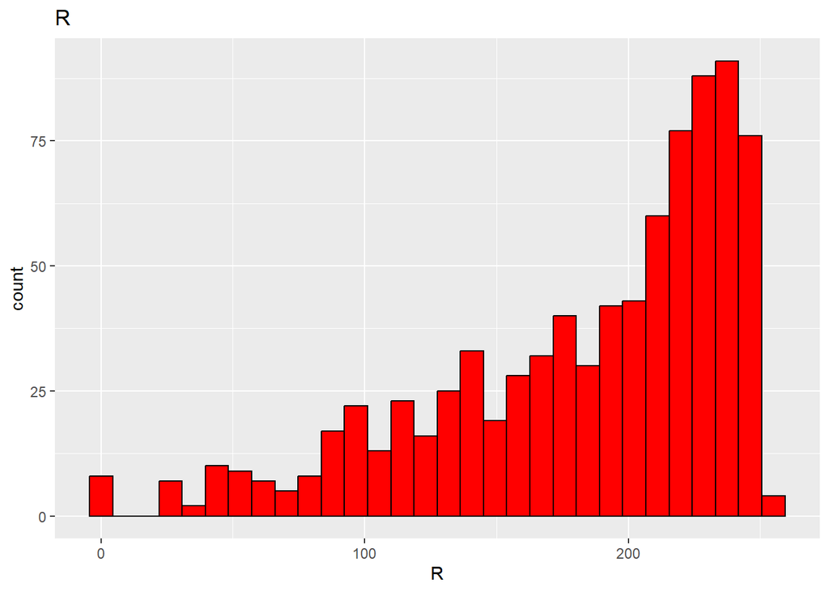

```r
# Red
df %>%
  ggplot() +
  geom_histogram(mapping=aes(x=R), color='black', fill='red') +
  ggtitle('R')
```

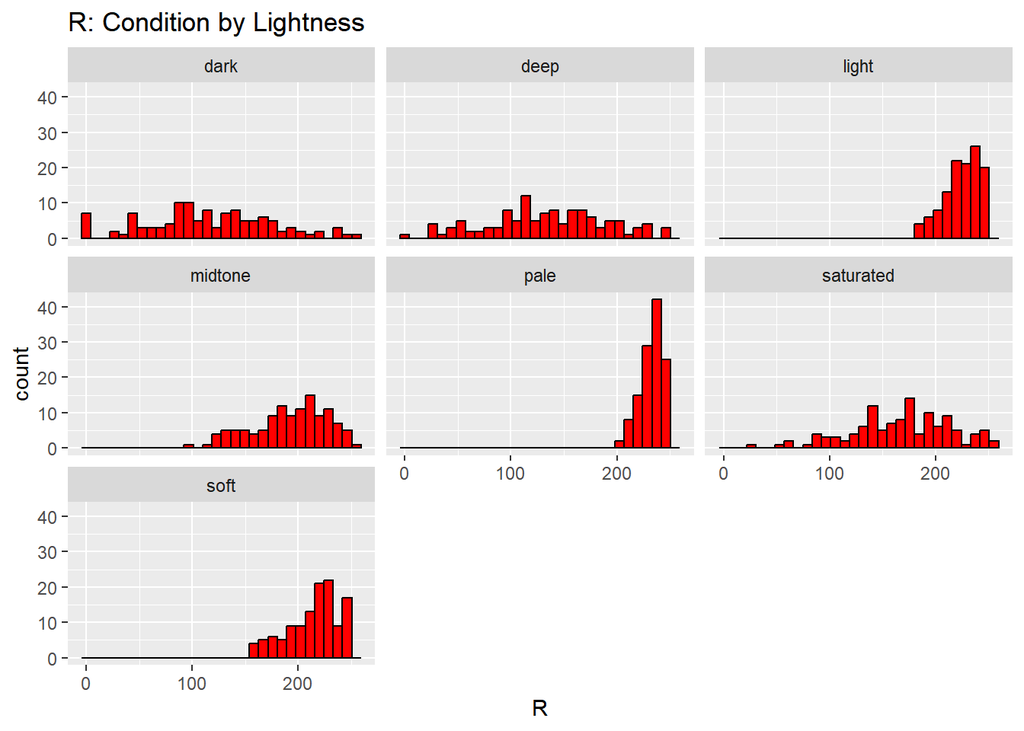

```r
df %>%
  ggplot() +
  geom_histogram(mapping=aes(x=R), color='black', fill='red') +
  facet_wrap(~Lightness) +
  ggtitle('R: Condition by Lightness')
```

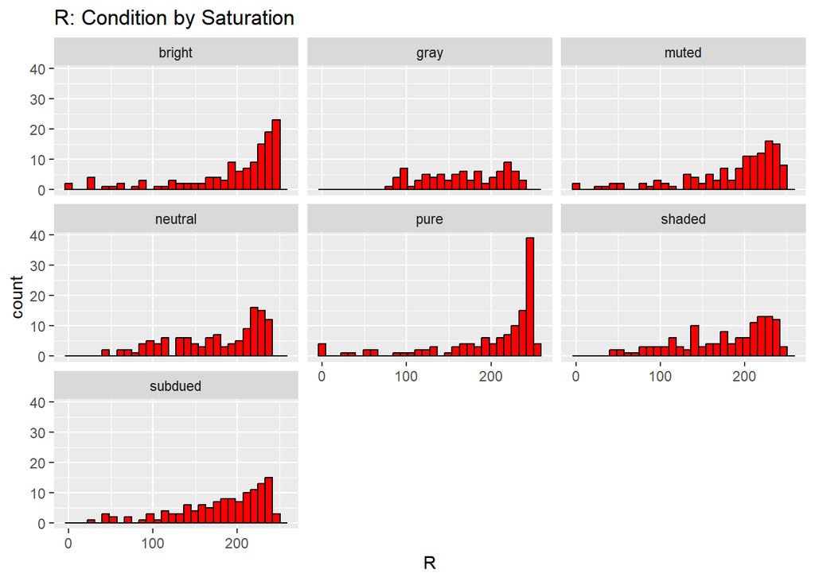

```r
df %>%
  ggplot() +
  geom_histogram(mapping=aes(x=R), color='black', fill='red') +
  facet_wrap(~Saturation) +
  ggtitle('R: Condition by Saturation')
```

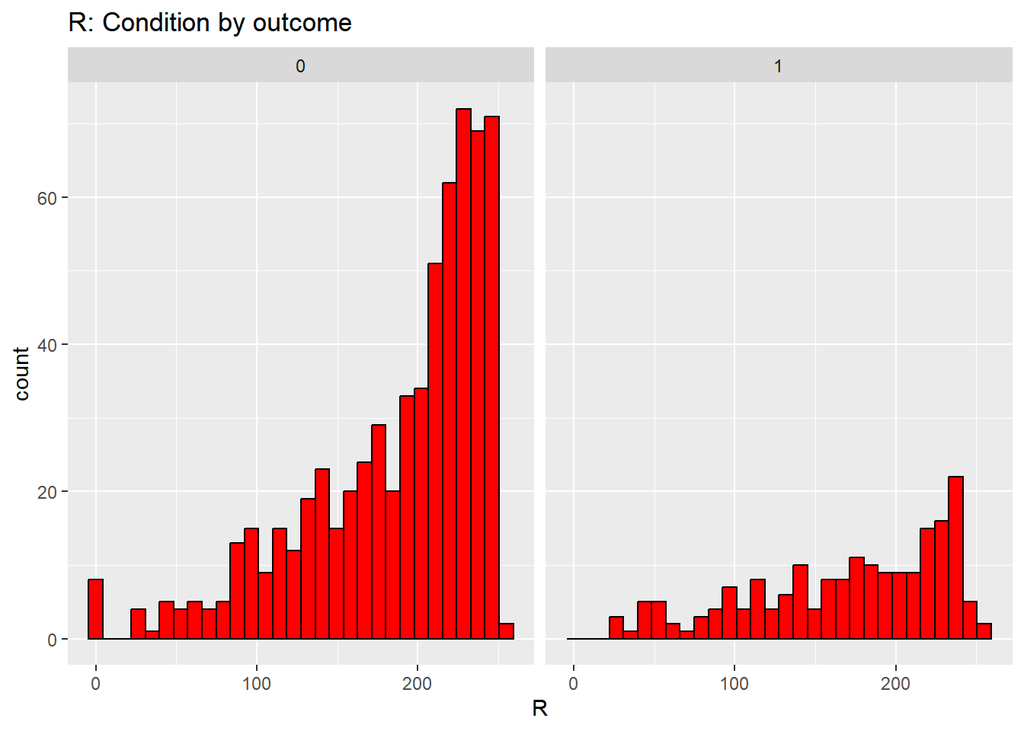

```r
df %>%
  ggplot() +
  geom_histogram(mapping=aes(x=R), color='black', fill='red') +
  facet_wrap(~outcome) +
  ggtitle('R: Condition by outcome')
```

Separating red by Lightness appears to make the data more Gaussian in shape, while Saturation gives some Gaussianity and some randomness. The distributions hold relatively well for the binary outcome condition - the shapes appear to be consistently skewed left, but there are much more non-events than events, so we cannot determine if the events is a true skewed left distribution or a random distribution.

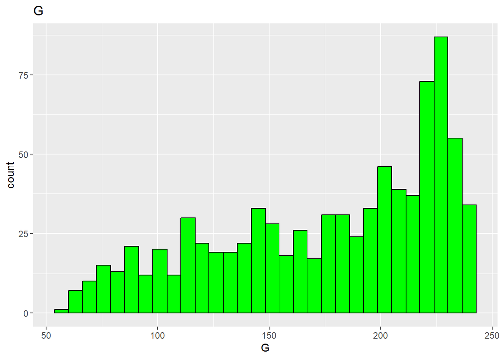

```r
# Green
df %>%
  ggplot() +
  geom_histogram(mapping=aes(x=G), color='black', fill='green') +
  ggtitle('G')
```

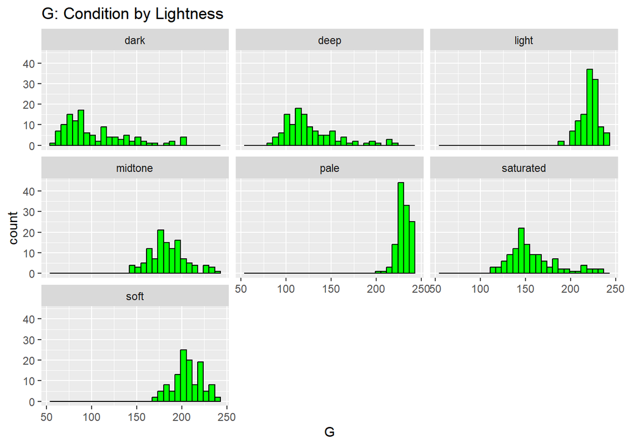

```r
df %>%
  ggplot() +
  geom_histogram(mapping=aes(x=G), color='black', fill='green') +
  facet_wrap(~Lightness) +
  ggtitle('G: Condition by Lightness')
```

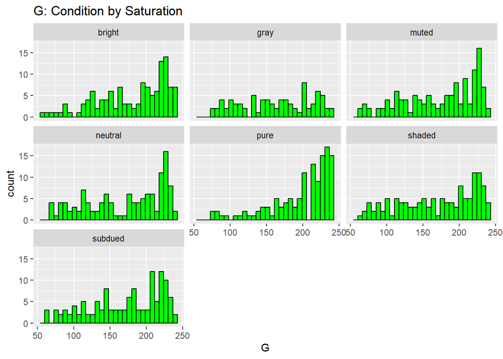

```r
df %>%
  ggplot() +
  geom_histogram(mapping=aes(x=G), color='black', fill='green') +
  facet_wrap(~Saturation) +
  ggtitle('G: Condition by Saturation')
```

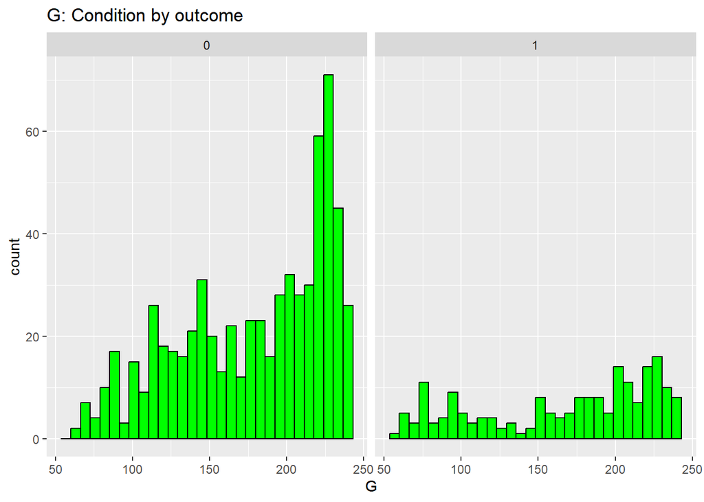

```r
df %>%
  ggplot() +
  geom_histogram(mapping=aes(x=G), color='black', fill='green') +
  facet_wrap(~outcome) +
  ggtitle('G: Condition by outcome')
```

Separating by Lightness gives G more Gaussianity while Saturation seems to hold the original shape of the distribution. The same thing applies for the binary condition as it did for red’s - the non-events appear to hold the same distribution with the majority of the data points, while the events appear to be randomly distributed with the chance of being skewed left.

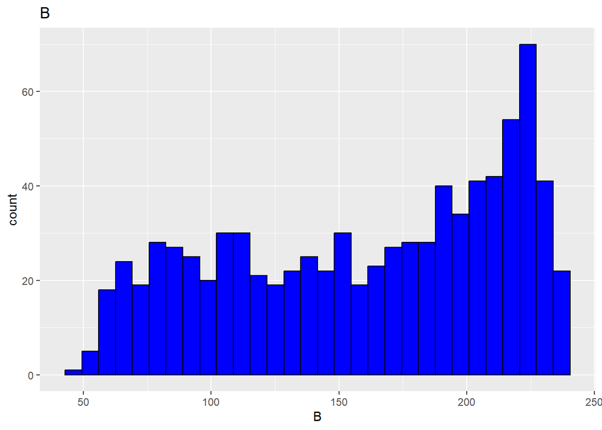

```r
# Blue
df %>%
  ggplot() +
  geom_histogram(mapping=aes(x=B), color='black', fill='blue') +
  ggtitle('B')
```

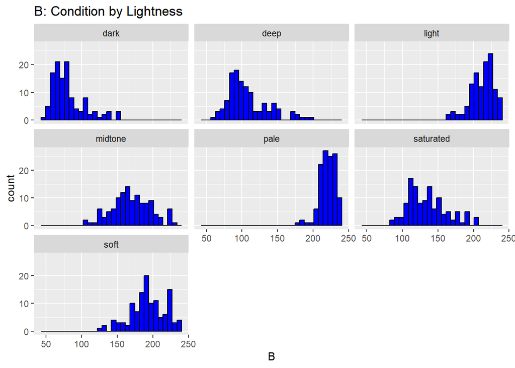

```r
df %>%
  ggplot() +
  geom_histogram(mapping=aes(x=B), color='black', fill='blue') +
  facet_wrap(~Lightness) +
  ggtitle('B: Condition by Lightness')
```

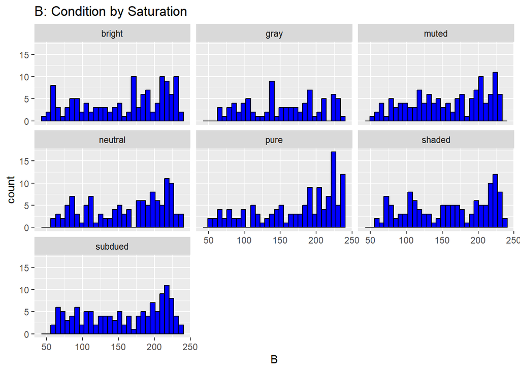

```r
df %>%
  ggplot() +
  geom_histogram(mapping=aes(x=B), color='black', fill='blue') +
  facet_wrap(~Saturation) +
  ggtitle('B: Condition by Saturation')
```

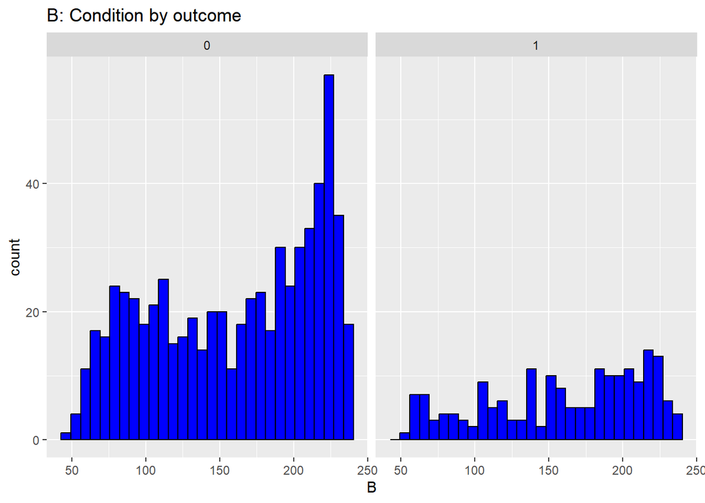

```r
df %>%
  ggplot() +
  geom_histogram(mapping=aes(x=B), color='black', fill='blue') +
  facet_wrap(~outcome) +
  ggtitle('B: Condition by outcome')
```

For blue, conditioning by Lightness appears to make the data more Gaussian, but more random for Saturation. The non-events here appear to have a bimodality in their distribution, while the events appear to be randomly distributed.

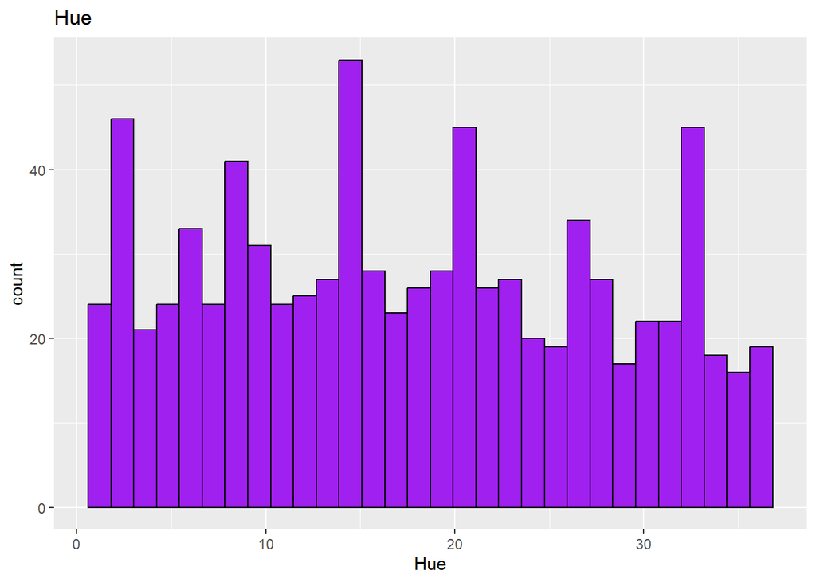

```r
# Hue
df %>%
  ggplot() +
  geom_histogram(mapping=aes(x=Hue), color='black', fill='purple') +
  ggtitle('Hue')
```

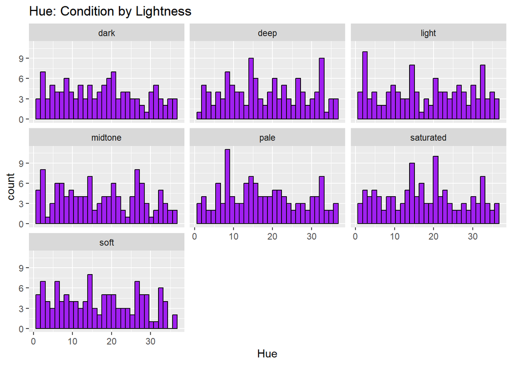

```r
df %>%
  ggplot() +
  geom_histogram(mapping=aes(x=Hue), color='black', fill='purple') +
  facet_wrap(~Lightness) +
  ggtitle('Hue: Condition by Lightness')
```

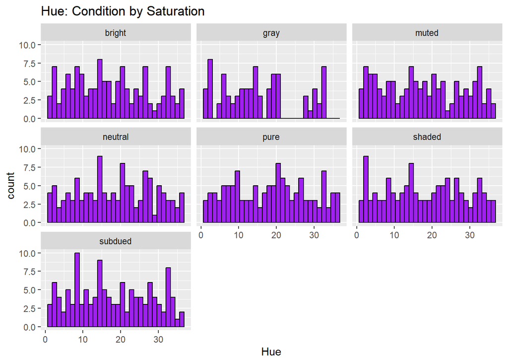

```r
df %>%
  ggplot() +
  geom_histogram(mapping=aes(x=Hue), color='black', fill='purple') +
  facet_wrap(~Saturation) +
  ggtitle('Hue: Condition by Saturation')
```

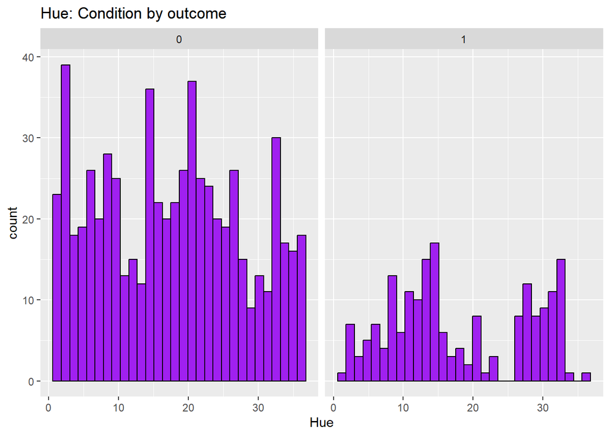

```r
df %>%
  ggplot() +
  geom_histogram(mapping=aes(x=Hue), color='black', fill='purple') +
  facet_wrap(~outcome) +
  ggtitle('Hue: Condition by outcome')
```

Hue seems to be randomly distributed regardless of the condition. When conditioning by outcome, I cannot really tell the shape of the non-events distribution. It appears that it could be trimodal in shape, or it could be considered random. However, there does appear to be three mini-distributions in the shape, which makes me lean towards trimodality in shape. The events appear bimodal in shape.

### C. Visualize the relationships between continuous inputs.

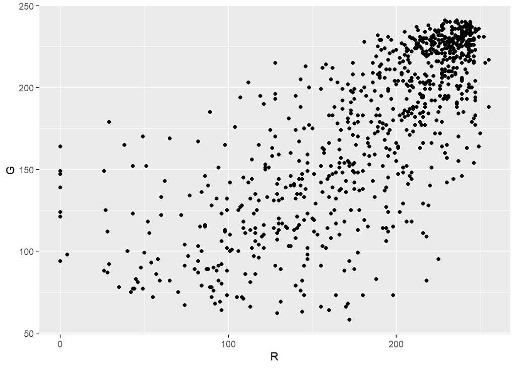

```r
df %>%
  ggplot(mapping=aes(x=R, y=G)) +
  geom_point()
```

There appears to be some correlation between R and G.

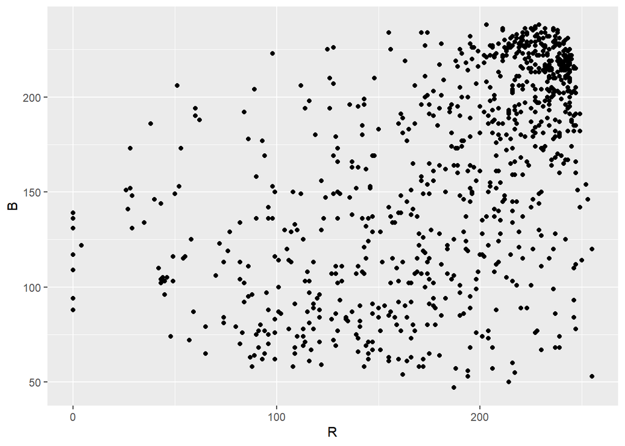

```r
df %>%
  ggplot(mapping=aes(x=R, y=B)) +
  geom_point()
```

There appears to be little to no correlation between R and B.

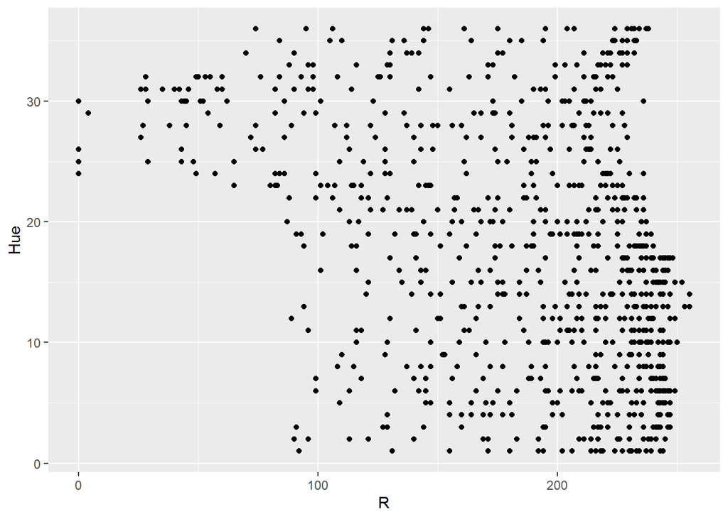

```r
df %>%
  ggplot(mapping=aes(x=R, y=Hue)) +
  geom_point()
```

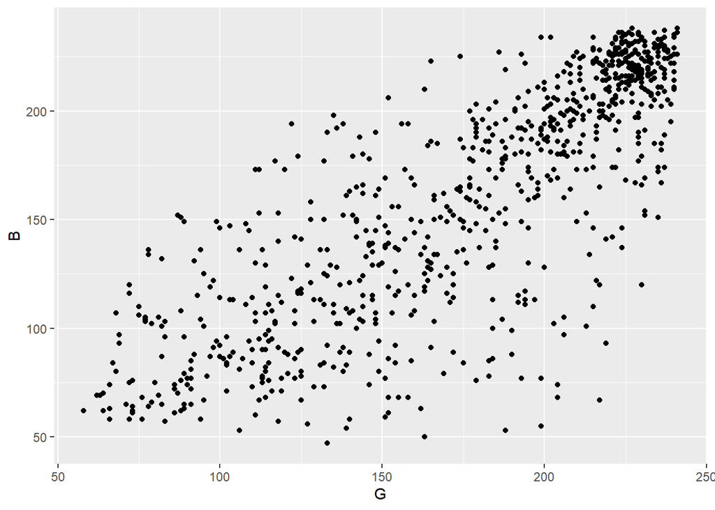

```r
df %>%
  ggplot(mapping=aes(x=G, y=B)) +
  geom_point()
```

There is a moderate amount of correlation between G and B.

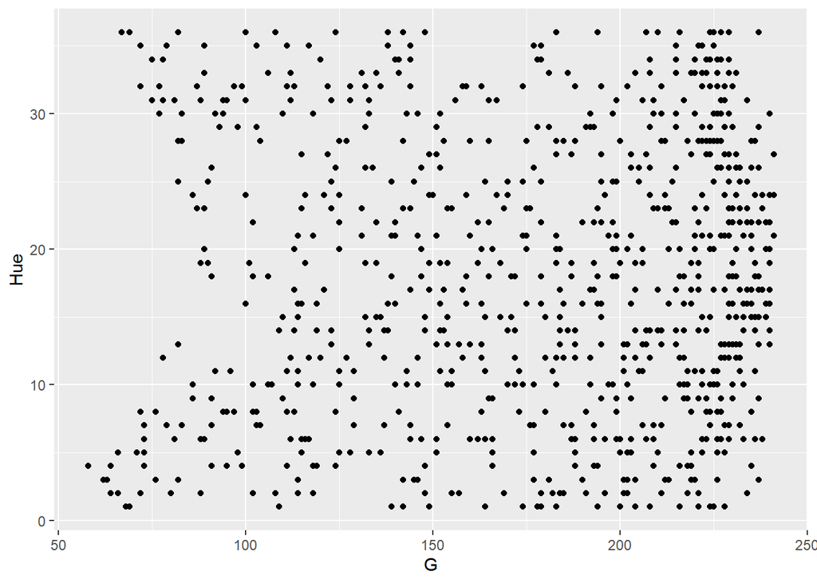

```r
df %>%
  ggplot(mapping=aes(x=G, y=Hue)) +
  geom_point()
```

There is no correlation between G and Hue.

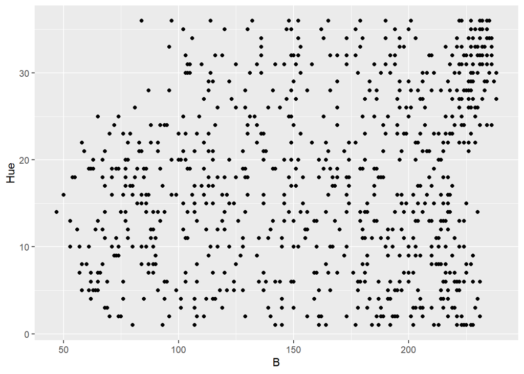

```r
df %>%
  ggplot(mapping=aes(x=B, y=Hue)) +
  geom_point()
```

### D. Relationships between continuous output/logit transformed response and continuous inputs

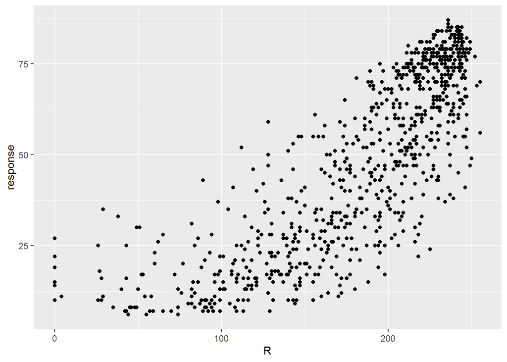

```r
df %>%
  ggplot(mapping=aes(x=R, y=response)) +
  geom_point()
```

There is a moderate correlation between R and response.

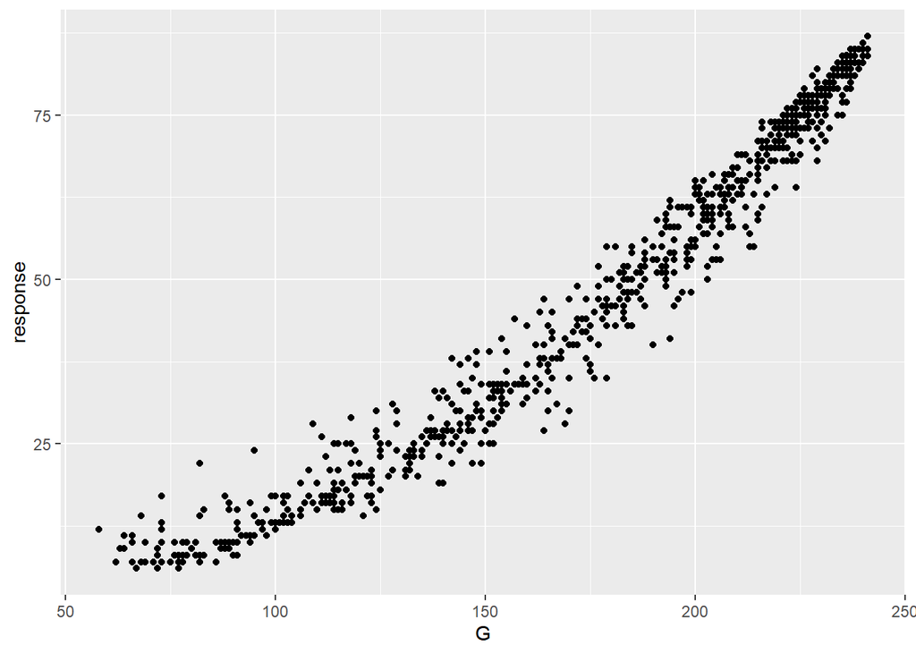

```r
df %>%
  ggplot(mapping=aes(x=G, y=response)) +
  geom_point()
```

There is a tight correlation between G and response.

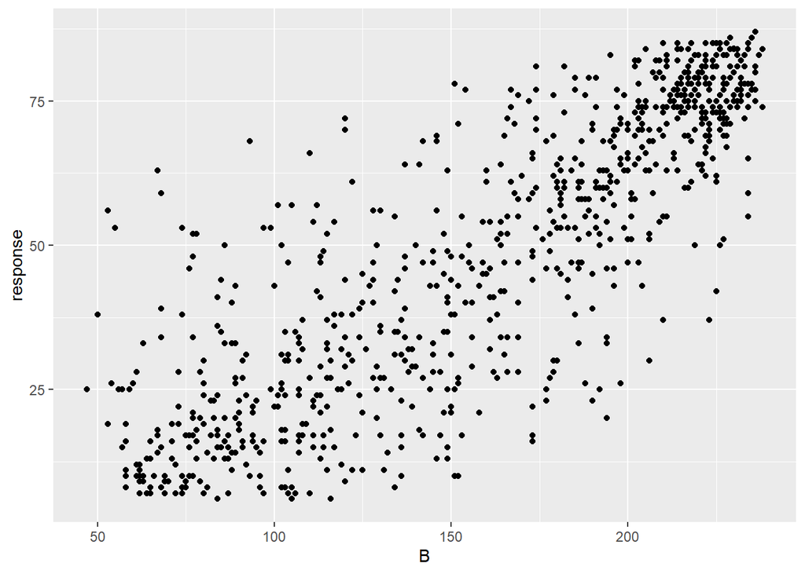

```r
df %>%
  ggplot(mapping=aes(x=B, y=response)) +
  geom_point()
```

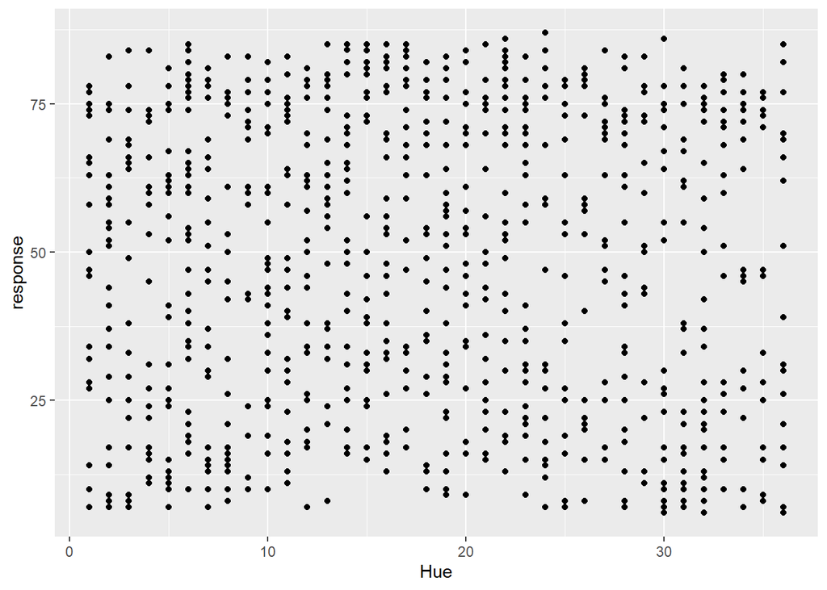

```r
df %>%
  ggplot(mapping=aes(x=Hue, y=response)) +
  geom_point()
```

There is no correlation between Hue and response.